# Risk Factor Analysis

## Outcome Variable

**Outcome Variable:** ever_stunted

## Predictor Variables

**Intervention Variable:** predexfd6

**Adjustment Set:**

- arm
- sex
- W_mage
- meducyrs
- feducyrs
- hhwealth_quart
- hfoodsec
- W_mhtcm
- vagbrth
- W_gagebrth
- W_birthwt
- W_birthlen
- W_nrooms
- W_nchldlt5
- month
- brthmon
- W_parity
- impfloor
- impsan
- safeh20
- delta_W_mage
- delta_meducyrs
- delta_feducyrs
- delta_hhwealth_quart
- delta_hfoodsec
- delta_W_mhtcm
- delta_vagbrth
- delta_W_gagebrth
- delta_W_birthwt
- delta_W_birthlen
- delta_W_nrooms
- delta_W_nchldlt5
- delta_month
- delta_brthmon
- delta_W_parity
- delta_impfloor
- delta_impsan
- delta_safeh20

## Stratifying Variables

The analysis was stratified on these variable(s):

- agecat
- studyid
- country

## Data Summary

| agecat | studyid | country | predexfd6 | ever_stunted | n_cell | n |
| --- | --- | --- | --- | --- | --- | --- |
| 0-6 months | ki0047075b-MAL-ED | BANGLADESH | 0 | 0 | 92 | 238 |
| 0-6 months | ki0047075b-MAL-ED | BANGLADESH | 0 | 1 | 21 | 238 |
| 0-6 months | ki0047075b-MAL-ED | BANGLADESH | 1 | 0 | 106 | 238 |
| 0-6 months | ki0047075b-MAL-ED | BANGLADESH | 1 | 1 | 19 | 238 |
| 0-6 months | ki0047075b-MAL-ED | BRAZIL | 0 | 0 | 159 | 212 |
| 0-6 months | ki0047075b-MAL-ED | BRAZIL | 0 | 1 | 17 | 212 |
| 0-6 months | ki0047075b-MAL-ED | BRAZIL | 1 | 0 | 32 | 212 |
| 0-6 months | ki0047075b-MAL-ED | BRAZIL | 1 | 1 | 4 | 212 |
| 0-6 months | ki0047075b-MAL-ED | INDIA | 0 | 0 | 181 | 234 |
| 0-6 months | ki0047075b-MAL-ED | INDIA | 0 | 1 | 34 | 234 |
| 0-6 months | ki0047075b-MAL-ED | INDIA | 1 | 0 | 13 | 234 |
| 0-6 months | ki0047075b-MAL-ED | INDIA | 1 | 1 | 6 | 234 |
| 0-6 months | ki0047075b-MAL-ED | NEPAL | 0 | 0 | 181 | 235 |
| 0-6 months | ki0047075b-MAL-ED | NEPAL | 0 | 1 | 25 | 235 |
| 0-6 months | ki0047075b-MAL-ED | NEPAL | 1 | 0 | 27 | 235 |
| 0-6 months | ki0047075b-MAL-ED | NEPAL | 1 | 1 | 2 | 235 |
| 0-6 months | ki0047075b-MAL-ED | PERU | 0 | 0 | 135 | 270 |
| 0-6 months | ki0047075b-MAL-ED | PERU | 0 | 1 | 21 | 270 |
| 0-6 months | ki0047075b-MAL-ED | PERU | 1 | 0 | 103 | 270 |
| 0-6 months | ki0047075b-MAL-ED | PERU | 1 | 1 | 11 | 270 |
| 0-6 months | ki0047075b-MAL-ED | SOUTH AFRICA | 0 | 0 | 221 | 248 |
| 0-6 months | ki0047075b-MAL-ED | SOUTH AFRICA | 0 | 1 | 24 | 248 |
| 0-6 months | ki0047075b-MAL-ED | SOUTH AFRICA | 1 | 0 | 1 | 248 |
| 0-6 months | ki0047075b-MAL-ED | SOUTH AFRICA | 1 | 1 | 2 | 248 |
| 0-6 months | ki0047075b-MAL-ED | TANZANIA, UNITED REPUBLIC OF | 0 | 0 | 208 | 248 |
| 0-6 months | ki0047075b-MAL-ED | TANZANIA, UNITED REPUBLIC OF | 0 | 1 | 38 | 248 |
| 0-6 months | ki0047075b-MAL-ED | TANZANIA, UNITED REPUBLIC OF | 1 | 0 | 2 | 248 |
| 0-6 months | ki0047075b-MAL-ED | TANZANIA, UNITED REPUBLIC OF | 1 | 1 | 0 | 248 |
| 0-6 months | ki1000108-CMC-V-BCS-2002 | INDIA | 1 | 0 | 14 | 19 |
| 0-6 months | ki1000108-CMC-V-BCS-2002 | INDIA | 1 | 1 | 5 | 19 |

[output cut: 168 more lines]

The following strata were considered:

- agecat: 0-24 months, studyid: ki0047075b-MAL-ED, country: BANGLADESH
- agecat: 0-24 months, studyid: ki0047075b-MAL-ED, country: BRAZIL
- agecat: 0-24 months, studyid: ki0047075b-MAL-ED, country: INDIA
- agecat: 0-24 months, studyid: ki0047075b-MAL-ED, country: NEPAL
- agecat: 0-24 months, studyid: ki0047075b-MAL-ED, country: PERU
- agecat: 0-24 months, studyid: ki0047075b-MAL-ED, country: SOUTH AFRICA
- agecat: 0-24 months, studyid: ki0047075b-MAL-ED, country: TANZANIA, UNITED REPUBLIC OF
- agecat: 0-24 months, studyid: ki1000108-CMC-V-BCS-2002, country: INDIA
- agecat: 0-24 months, studyid: ki1000108-IRC, country: INDIA
- agecat: 0-24 months, studyid: ki1000109-EE, country: PAKISTAN
- agecat: 0-24 months, studyid: ki1000304b-SAS-CompFeed, country: INDIA
- agecat: 0-24 months, studyid: ki1000304b-SAS-FoodSuppl, country: INDIA
- agecat: 0-24 months, studyid: ki1017093b-PROVIDE, country: BANGLADESH
- agecat: 0-24 months, studyid: ki1101329-Keneba, country: GAMBIA
- agecat: 0-24 months, studyid: ki1113344-GMS-Nepal, country: NEPAL
- agecat: 0-24 months, studyid: ki1148112-LCNI-5, country: MALAWI
- agecat: 0-24 months, studyid: kiGH5241-JiVitA-3, country: BANGLADESH
- agecat: 0-24 months, studyid: kiGH5241-JiVitA-4, country: BANGLADESH
- agecat: 0-6 months, studyid: ki0047075b-MAL-ED, country: BANGLADESH
- agecat: 0-6 months, studyid: ki0047075b-MAL-ED, country: BRAZIL
- agecat: 0-6 months, studyid: ki0047075b-MAL-ED, country: INDIA
- agecat: 0-6 months, studyid: ki0047075b-MAL-ED, country: NEPAL
- agecat: 0-6 months, studyid: ki0047075b-MAL-ED, country: PERU
- agecat: 0-6 months, studyid: ki0047075b-MAL-ED, country: SOUTH AFRICA
- agecat: 0-6 months, studyid: ki0047075b-MAL-ED, country: TANZANIA, UNITED REPUBLIC OF
- agecat: 0-6 months, studyid: ki1000108-CMC-V-BCS-2002, country: INDIA
- agecat: 0-6 months, studyid: ki1000108-IRC, country: INDIA
- agecat: 0-6 months, studyid: ki1000109-EE, country: PAKISTAN
- agecat: 0-6 months, studyid: ki1000304b-SAS-CompFeed, country: INDIA
- agecat: 0-6 months, studyid: ki1000304b-SAS-FoodSuppl, country: INDIA
- agecat: 0-6 months, studyid: ki1017093b-PROVIDE, country: BANGLADESH
- agecat: 0-6 months, studyid: ki1101329-Keneba, country: GAMBIA
- agecat: 0-6 months, studyid: ki1113344-GMS-Nepal, country: NEPAL
- agecat: 0-6 months, studyid: ki1148112-LCNI-5, country: MALAWI
- agecat: 0-6 months, studyid: kiGH5241-JiVitA-3, country: BANGLADESH
- agecat: 0-6 months, studyid: kiGH5241-JiVitA-4, country: BANGLADESH
- agecat: 6-24 months, studyid: ki0047075b-MAL-ED, country: BANGLADESH
- agecat: 6-24 months, studyid: ki0047075b-MAL-ED, country: BRAZIL
- agecat: 6-24 months, studyid: ki0047075b-MAL-ED, country: INDIA
- agecat: 6-24 months, studyid: ki0047075b-MAL-ED, country: NEPAL
- agecat: 6-24 months, studyid: ki0047075b-MAL-ED, country: PERU
- agecat: 6-24 months, studyid: ki0047075b-MAL-ED, country: SOUTH AFRICA
- agecat: 6-24 months, studyid: ki0047075b-MAL-ED, country: TANZANIA, UNITED REPUBLIC OF
- agecat: 6-24 months, studyid: ki1000108-CMC-V-BCS-2002, country: INDIA
- agecat: 6-24 months, studyid: ki1000108-IRC, country: INDIA
- agecat: 6-24 months, studyid: ki1000109-EE, country: PAKISTAN
- agecat: 6-24 months, studyid: ki1000304b-SAS-CompFeed, country: INDIA
- agecat: 6-24 months, studyid: ki1000304b-SAS-FoodSuppl, country: INDIA
- agecat: 6-24 months, studyid: ki1017093b-PROVIDE, country: BANGLADESH
- agecat: 6-24 months, studyid: ki1101329-Keneba, country: GAMBIA
- agecat: 6-24 months, studyid: ki1113344-GMS-Nepal, country: NEPAL
- agecat: 6-24 months, studyid: ki1148112-LCNI-5, country: MALAWI
- agecat: 6-24 months, studyid: kiGH5241-JiVitA-3, country: BANGLADESH
- agecat: 6-24 months, studyid: kiGH5241-JiVitA-4, country: BANGLADESH

### Dropped Strata

Some strata were dropped due to rare outcomes:

- agecat: 0-6 months, studyid: ki0047075b-MAL-ED, country: BRAZIL
- agecat: 0-6 months, studyid: ki0047075b-MAL-ED, country: NEPAL
- agecat: 0-6 months, studyid: ki0047075b-MAL-ED, country: SOUTH AFRICA
- agecat: 0-6 months, studyid: ki0047075b-MAL-ED, country: TANZANIA, UNITED REPUBLIC OF
- agecat: 0-6 months, studyid: ki1000108-IRC, country: INDIA
- agecat: 6-24 months, studyid: ki0047075b-MAL-ED, country: BRAZIL
- agecat: 6-24 months, studyid: ki0047075b-MAL-ED, country: NEPAL
- agecat: 6-24 months, studyid: ki0047075b-MAL-ED, country: SOUTH AFRICA
- agecat: 6-24 months, studyid: ki0047075b-MAL-ED, country: TANZANIA, UNITED REPUBLIC OF
- agecat: 6-24 months, studyid: ki1000108-IRC, country: INDIA
- agecat: 6-24 months, studyid: ki1000304b-SAS-CompFeed, country: INDIA
- agecat: 0-24 months, studyid: ki0047075b-MAL-ED, country: SOUTH AFRICA
- agecat: 0-24 months, studyid: ki0047075b-MAL-ED, country: TANZANIA, UNITED REPUBLIC OF

## Methods Detail

We’re interested in the causal parameters $E[Y_a]$ for all values of $a \in \mathcal{A}$. These parameters represent the mean outcome if, possibly contrary to fact, we intervened to set all units to have $A=a$. Under the randomization and positivity assumptions, these are identified by the statistical parameters $\psi_a=E_W[E_{Y|A,W}(Y|A=a,W)]$. In addition, we’re interested in the mean of $Y$, $E[Y]$ under no intervention (the observed mean). We will estimate these parameters by using SuperLearner to fit the relevant likelihood factors – $E_{Y|A,W}(Y|A=a,W)$ and $p(A=a|W)$, and then updating our likelihood fit using a joint TMLE.

For unadjusted analyses ($W=\{\}$), initial likelihoods were estimated using Lrnr_glm to estimate the simple $E(Y|A)$ and Lrnr_mean to estimate $p(A)$. For adjusted analyses, a small library containing Lrnr_glmnet, Lrnr_xgboost, and Lrnr_mean was used.

Having estimated these parameters, we will then use the delta method to estimate relative risks and attributable risks relative to a prespecified baseline level of $A$.

```
##          ever_stunted
## predexfd6  0  1
##         0  0  0
##         1  5 14
##          ever_stunted
## predexfd6 0 1
##         0 7 7
##         1 0 0
```

```
##          ever_stunted
## predexfd6   0   1
##         0  39 145
##         1   0   0
##          ever_stunted
## predexfd6  0  1
##         0  0  0
##         1 14  5
```

```
##          ever_stunted
## predexfd6  0  1
##         0 95 88
##         1  0  0
##          ever_stunted
## predexfd6 0 1
##         0 0 0
##         1 5 8
##          ever_stunted
## predexfd6  0  1
##         0 37 51
##         1  0  0
```

# Results Detail

## Results Plots

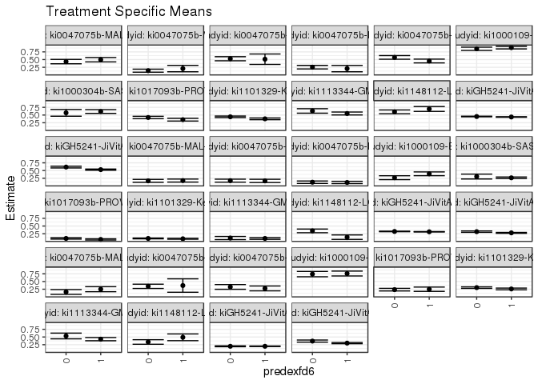

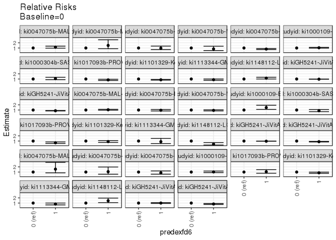

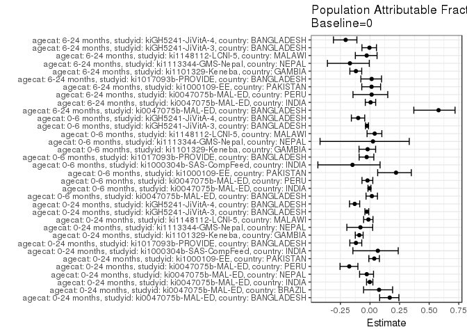

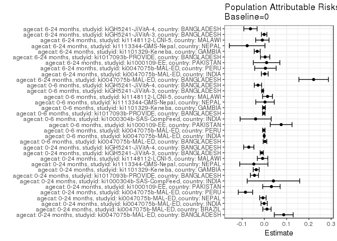

## Results Table

### Parameter: TSM

| agecat | studyid | country | intervention_level | baseline_level | estimate | ci_lower | ci_upper |
| --- | --- | --- | --- | --- | --- | --- | --- |
| 0-24 months | ki0047075b-MAL-ED | BANGLADESH | 0 | NA | 0.4341131 | 0.3626112 | 0.5056150 |
| 0-24 months | ki0047075b-MAL-ED | BANGLADESH | 1 | NA | 0.4952857 | 0.4239689 | 0.5666026 |
| 0-24 months | ki0047075b-MAL-ED | BRAZIL | 0 | NA | 0.1393893 | 0.0901248 | 0.1886538 |
| 0-24 months | ki0047075b-MAL-ED | BRAZIL | 1 | NA | 0.2077800 | 0.1033109 | 0.3122491 |
| 0-24 months | ki0047075b-MAL-ED | INDIA | 0 | NA | 0.5267404 | 0.4605421 | 0.5929387 |
| 0-24 months | ki0047075b-MAL-ED | INDIA | 1 | NA | 0.5116977 | 0.3426580 | 0.6807374 |
| 0-24 months | ki0047075b-MAL-ED | NEPAL | 0 | NA | 0.2535778 | 0.1960356 | 0.3111200 |
| 0-24 months | ki0047075b-MAL-ED | NEPAL | 1 | NA | 0.2066527 | 0.1032257 | 0.3100797 |
| 0-24 months | ki0047075b-MAL-ED | PERU | 0 | NA | 0.5702418 | 0.5109722 | 0.6295114 |
| 0-24 months | ki0047075b-MAL-ED | PERU | 1 | NA | 0.4523584 | 0.3908068 | 0.5139101 |
| 0-24 months | ki1000109-EE | PAKISTAN | 0 | NA | 0.8496862 | 0.7966622 | 0.9027101 |
| 0-24 months | ki1000109-EE | PAKISTAN | 1 | NA | 0.8864591 | 0.8458641 | 0.9270540 |
| 0-24 months | ki1000304b-SAS-CompFeed | INDIA | 0 | NA | 0.5719420 | 0.4622093 | 0.6816747 |
| 0-24 months | ki1000304b-SAS-CompFeed | INDIA | 1 | NA | 0.6149058 | 0.5538349 | 0.6759768 |
| 0-24 months | ki1017093b-PROVIDE | BANGLADESH | 0 | NA | 0.4203763 | 0.3812622 | 0.4594904 |
| 0-24 months | ki1017093b-PROVIDE | BANGLADESH | 1 | NA | 0.3501331 | 0.3056249 | 0.3946413 |
| 0-24 months | ki1101329-Keneba | GAMBIA | 0 | NA | 0.4431218 | 0.4189999 | 0.4672437 |
| 0-24 months | ki1101329-Keneba | GAMBIA | 1 | NA | 0.3772899 | 0.3495032 | 0.4050765 |
| 0-24 months | ki1113344-GMS-Nepal | NEPAL | 0 | NA | 0.6332601 | 0.5608073 | 0.7057129 |
| 0-24 months | ki1113344-GMS-Nepal | NEPAL | 1 | NA | 0.5508100 | 0.5035300 | 0.5980900 |
| 0-24 months | ki1148112-LCNI-5 | MALAWI | 0 | NA | 0.6036486 | 0.5421303 | 0.6651668 |
| 0-24 months | ki1148112-LCNI-5 | MALAWI | 1 | NA | 0.6971865 | 0.6190678 | 0.7753053 |
| 0-24 months | kiGH5241-JiVitA-3 | BANGLADESH | 0 | NA | 0.4523002 | 0.4422225 | 0.4623779 |
| 0-24 months | kiGH5241-JiVitA-3 | BANGLADESH | 1 | NA | 0.4367988 | 0.4289798 | 0.4446178 |
| 0-24 months | kiGH5241-JiVitA-4 | BANGLADESH | 0 | NA | 0.6126872 | 0.5839667 | 0.6414077 |
| 0-24 months | kiGH5241-JiVitA-4 | BANGLADESH | 1 | NA | 0.5293277 | 0.5111735 | 0.5474818 |
| 0-6 months | ki0047075b-MAL-ED | BANGLADESH | 0 | NA | 0.1653948 | 0.1181963 | 0.2125933 |
| 0-6 months | ki0047075b-MAL-ED | BANGLADESH | 1 | NA | 0.1739340 | 0.1252802 | 0.2225878 |
| 0-6 months | ki0047075b-MAL-ED | INDIA | 0 | NA | 0.1717205 | 0.1232258 | 0.2202153 |
| 0-6 months | ki0047075b-MAL-ED | INDIA | 1 | NA | 0.1637701 | 0.1111392 | 0.2164010 |
| 0-6 months | ki0047075b-MAL-ED | PERU | 0 | NA | 0.1210154 | 0.0807021 | 0.1613287 |
| 0-6 months | ki0047075b-MAL-ED | PERU | 1 | NA | 0.1128876 | 0.0756903 | 0.1500849 |
| 0-6 months | ki1000109-EE | PAKISTAN | 0 | NA | 0.2675907 | 0.2045610 | 0.3306203 |
| 0-6 months | ki1000109-EE | PAKISTAN | 1 | NA | 0.3937760 | 0.3329066 | 0.4546454 |
| 0-6 months | ki1000304b-SAS-CompFeed | INDIA | 0 | NA | 0.3050953 | 0.2256621 | 0.3845286 |
| 0-6 months | ki1000304b-SAS-CompFeed | INDIA | 1 | NA | 0.2641883 | 0.2380933 | 0.2902834 |
| 0-6 months | ki1017093b-PROVIDE | BANGLADESH | 0 | NA | 0.0969158 | 0.0748930 | 0.1189387 |
| 0-6 months | ki1017093b-PROVIDE | BANGLADESH | 1 | NA | 0.0646469 | 0.0451301 | 0.0841637 |
| 0-6 months | ki1101329-Keneba | GAMBIA | 0 | NA | 0.0967679 | 0.0830359 | 0.1105000 |
| 0-6 months | ki1101329-Keneba | GAMBIA | 1 | NA | 0.0863799 | 0.0709835 | 0.1017763 |
| 0-6 months | ki1113344-GMS-Nepal | NEPAL | 0 | NA | 0.1104270 | 0.0598532 | 0.1610008 |
| 0-6 months | ki1113344-GMS-Nepal | NEPAL | 1 | NA | 0.0970629 | 0.0686920 | 0.1254338 |
| 0-6 months | ki1148112-LCNI-5 | MALAWI | 0 | NA | 0.3424953 | 0.2827153 | 0.4022753 |
| 0-6 months | ki1148112-LCNI-5 | MALAWI | 1 | NA | 0.1382550 | 0.0656923 | 0.2108178 |
| 0-6 months | kiGH5241-JiVitA-3 | BANGLADESH | 0 | NA | 0.3241132 | 0.3163331 | 0.3318932 |
| 0-6 months | kiGH5241-JiVitA-3 | BANGLADESH | 1 | NA | 0.3131643 | 0.3063889 | 0.3199396 |
| 0-6 months | kiGH5241-JiVitA-4 | BANGLADESH | 0 | NA | 0.3172990 | 0.2946840 | 0.3399139 |
| 0-6 months | kiGH5241-JiVitA-4 | BANGLADESH | 1 | NA | 0.2782175 | 0.2632871 | 0.2931479 |
| 6-24 months | ki0047075b-MAL-ED | BANGLADESH | 0 | NA | 0.1608521 | 0.0828830 | 0.2388212 |
| 6-24 months | ki0047075b-MAL-ED | BANGLADESH | 1 | NA | 0.2504807 | 0.1686972 | 0.3322641 |
| 6-24 months | ki0047075b-MAL-ED | INDIA | 0 | NA | 0.3437897 | 0.2746168 | 0.4129625 |
| 6-24 months | ki0047075b-MAL-ED | INDIA | 1 | NA | 0.3695556 | 0.1520622 | 0.5870489 |
| 6-24 months | ki0047075b-MAL-ED | PERU | 0 | NA | 0.3243423 | 0.2481023 | 0.4005822 |
| 6-24 months | ki0047075b-MAL-ED | PERU | 1 | NA | 0.2755004 | 0.1965354 | 0.3544654 |
| 6-24 months | ki1000109-EE | PAKISTAN | 0 | NA | 0.7400564 | 0.6532875 | 0.8268252 |
| 6-24 months | ki1000109-EE | PAKISTAN | 1 | NA | 0.7586930 | 0.6793055 | 0.8380804 |
| 6-24 months | ki1017093b-PROVIDE | BANGLADESH | 0 | NA | 0.2360536 | 0.1937440 | 0.2783631 |
| 6-24 months | ki1017093b-PROVIDE | BANGLADESH | 1 | NA | 0.2497158 | 0.1802455 | 0.3191860 |
| 6-24 months | ki1101329-Keneba | GAMBIA | 0 | NA | 0.3020560 | 0.2773220 | 0.3267899 |
| 6-24 months | ki1101329-Keneba | GAMBIA | 1 | NA | 0.2584833 | 0.2298944 | 0.2870722 |
| 6-24 months | ki1113344-GMS-Nepal | NEPAL | 0 | NA | 0.5332270 | 0.4408521 | 0.6256020 |
| 6-24 months | ki1113344-GMS-Nepal | NEPAL | 1 | NA | 0.4305484 | 0.3780923 | 0.4830044 |
| 6-24 months | ki1148112-LCNI-5 | MALAWI | 0 | NA | 0.3388468 | 0.2651406 | 0.4125530 |
| 6-24 months | ki1148112-LCNI-5 | MALAWI | 1 | NA | 0.4899813 | 0.3814719 | 0.5984907 |
| 6-24 months | kiGH5241-JiVitA-3 | BANGLADESH | 0 | NA | 0.1985648 | 0.1845554 | 0.2125742 |
| 6-24 months | kiGH5241-JiVitA-3 | BANGLADESH | 1 | NA | 0.1986554 | 0.1900221 | 0.2072888 |
| 6-24 months | kiGH5241-JiVitA-4 | BANGLADESH | 0 | NA | 0.3668657 | 0.3325634 | 0.4011680 |
| 6-24 months | kiGH5241-JiVitA-4 | BANGLADESH | 1 | NA | 0.3015345 | 0.2823647 | 0.3207043 |

### Parameter: E(Y)

| agecat | studyid | country | intervention_level | baseline_level | estimate | ci_lower | ci_upper |
| --- | --- | --- | --- | --- | --- | --- | --- |
| 0-24 months | ki0047075b-MAL-ED | BANGLADESH | NA | NA | 0.5210084 | 0.4574079 | 0.5846089 |
| 0-24 months | ki0047075b-MAL-ED | BRAZIL | NA | NA | 0.1509434 | 0.1026395 | 0.1992473 |
| 0-24 months | ki0047075b-MAL-ED | INDIA | NA | NA | 0.5256410 | 0.4615247 | 0.5897573 |
| 0-24 months | ki0047075b-MAL-ED | NEPAL | NA | NA | 0.2468085 | 0.1915661 | 0.3020510 |
| 0-24 months | ki0047075b-MAL-ED | PERU | NA | NA | 0.4851852 | 0.4254609 | 0.5449095 |
| 0-24 months | ki1000109-EE | PAKISTAN | NA | NA | 0.8812665 | 0.8486571 | 0.9138759 |
| 0-24 months | ki1000304b-SAS-CompFeed | INDIA | NA | NA | 0.6126126 | 0.5552216 | 0.6700036 |
| 0-24 months | ki1017093b-PROVIDE | BANGLADESH | NA | NA | 0.3757143 | 0.3398113 | 0.4116172 |
| 0-24 months | ki1101329-Keneba | GAMBIA | NA | NA | 0.4062640 | 0.3858979 | 0.4266301 |
| 0-24 months | ki1113344-GMS-Nepal | NEPAL | NA | NA | 0.5858407 | 0.5451887 | 0.6264927 |
| 0-24 months | ki1148112-LCNI-5 | MALAWI | NA | NA | 0.5955882 | 0.5371566 | 0.6540199 |
| 0-24 months | kiGH5241-JiVitA-3 | BANGLADESH | NA | NA | 0.4405521 | 0.4330109 | 0.4480933 |
| 0-24 months | kiGH5241-JiVitA-4 | BANGLADESH | NA | NA | 0.5425667 | 0.5251549 | 0.5599785 |
| 0-6 months | ki0047075b-MAL-ED | BANGLADESH | NA | NA | 0.1680672 | 0.1204615 | 0.2156730 |
| 0-6 months | ki0047075b-MAL-ED | INDIA | NA | NA | 0.1709402 | 0.1226026 | 0.2192778 |
| 0-6 months | ki0047075b-MAL-ED | PERU | NA | NA | 0.1185185 | 0.0798932 | 0.1571438 |
| 0-6 months | ki1000109-EE | PAKISTAN | NA | NA | 0.3430079 | 0.2951521 | 0.3908637 |
| 0-6 months | ki1000304b-SAS-CompFeed | INDIA | NA | NA | 0.2657658 | 0.2387383 | 0.2927933 |
| 0-6 months | ki1017093b-PROVIDE | BANGLADESH | NA | NA | 0.0942857 | 0.0726222 | 0.1159492 |
| 0-6 months | ki1101329-Keneba | GAMBIA | NA | NA | 0.0948546 | 0.0827041 | 0.1070051 |
| 0-6 months | ki1113344-GMS-Nepal | NEPAL | NA | NA | 0.1132743 | 0.0871185 | 0.1394302 |
| 0-6 months | ki1148112-LCNI-5 | MALAWI | NA | NA | 0.3566176 | 0.2995882 | 0.4136471 |
| 0-6 months | kiGH5241-JiVitA-3 | BANGLADESH | NA | NA | 0.3161210 | 0.3094208 | 0.3228212 |
| 0-6 months | kiGH5241-JiVitA-4 | BANGLADESH | NA | NA | 0.2885593 | 0.2738711 | 0.3032475 |
| 6-24 months | ki0047075b-MAL-ED | BANGLADESH | NA | NA | 0.3821990 | 0.3131049 | 0.4512930 |
| 6-24 months | ki0047075b-MAL-ED | INDIA | NA | NA | 0.3455497 | 0.2779313 | 0.4131681 |
| 6-24 months | ki0047075b-MAL-ED | PERU | NA | NA | 0.3289474 | 0.2678283 | 0.3900664 |
| 6-24 months | ki1000109-EE | PAKISTAN | NA | NA | 0.7500000 | 0.6879377 | 0.8120623 |
| 6-24 months | ki1017093b-PROVIDE | BANGLADESH | NA | NA | 0.2394366 | 0.2018814 | 0.2769918 |
| 6-24 months | ki1101329-Keneba | GAMBIA | NA | NA | 0.2699454 | 0.2496004 | 0.2902903 |
| 6-24 months | ki1113344-GMS-Nepal | NEPAL | NA | NA | 0.4559471 | 0.4100826 | 0.5018117 |
| 6-24 months | ki1148112-LCNI-5 | MALAWI | NA | NA | 0.3296089 | 0.2605529 | 0.3986650 |
| 6-24 months | kiGH5241-JiVitA-3 | BANGLADESH | NA | NA | 0.1976216 | 0.1895303 | 0.2057128 |
| 6-24 months | kiGH5241-JiVitA-4 | BANGLADESH | NA | NA | 0.3042547 | 0.2863424 | 0.3221671 |

### Parameter: RR

| agecat | studyid | country | intervention_level | baseline_level | estimate | ci_lower | ci_upper |
| --- | --- | --- | --- | --- | --- | --- | --- |
| 0-24 months | ki0047075b-MAL-ED | BANGLADESH | 0 | 0 | 1.0000000 | 1.0000000 | 1.0000000 |
| 0-24 months | ki0047075b-MAL-ED | BANGLADESH | 1 | 0 | 1.1409141 | 0.9634299 | 1.3510946 |
| 0-24 months | ki0047075b-MAL-ED | BRAZIL | 0 | 0 | 1.0000000 | 1.0000000 | 1.0000000 |
| 0-24 months | ki0047075b-MAL-ED | BRAZIL | 1 | 0 | 1.4906451 | 0.8617383 | 2.5785353 |
| 0-24 months | ki0047075b-MAL-ED | INDIA | 0 | 0 | 1.0000000 | 1.0000000 | 1.0000000 |
| 0-24 months | ki0047075b-MAL-ED | INDIA | 1 | 0 | 0.9714419 | 0.6933016 | 1.3611671 |
| 0-24 months | ki0047075b-MAL-ED | NEPAL | 0 | 0 | 1.0000000 | 1.0000000 | 1.0000000 |
| 0-24 months | ki0047075b-MAL-ED | NEPAL | 1 | 0 | 0.8149478 | 0.4946859 | 1.3425487 |
| 0-24 months | ki0047075b-MAL-ED | PERU | 0 | 0 | 1.0000000 | 1.0000000 | 1.0000000 |
| 0-24 months | ki0047075b-MAL-ED | PERU | 1 | 0 | 0.7932748 | 0.6987533 | 0.9005824 |
| 0-24 months | ki1000109-EE | PAKISTAN | 0 | 0 | 1.0000000 | 1.0000000 | 1.0000000 |
| 0-24 months | ki1000109-EE | PAKISTAN | 1 | 0 | 1.0432782 | 0.9657705 | 1.1270063 |
| 0-24 months | ki1000304b-SAS-CompFeed | INDIA | 0 | 0 | 1.0000000 | 1.0000000 | 1.0000000 |
| 0-24 months | ki1000304b-SAS-CompFeed | INDIA | 1 | 0 | 1.0751191 | 0.8670756 | 1.3330800 |
| 0-24 months | ki1017093b-PROVIDE | BANGLADESH | 0 | 0 | 1.0000000 | 1.0000000 | 1.0000000 |
| 0-24 months | ki1017093b-PROVIDE | BANGLADESH | 1 | 0 | 0.8329039 | 0.7280940 | 0.9528013 |
| 0-24 months | ki1101329-Keneba | GAMBIA | 0 | 0 | 1.0000000 | 1.0000000 | 1.0000000 |
| 0-24 months | ki1101329-Keneba | GAMBIA | 1 | 0 | 0.8514360 | 0.7818486 | 0.9272169 |
| 0-24 months | ki1113344-GMS-Nepal | NEPAL | 0 | 0 | 1.0000000 | 1.0000000 | 1.0000000 |
| 0-24 months | ki1113344-GMS-Nepal | NEPAL | 1 | 0 | 0.8698005 | 0.7539776 | 1.0034156 |
| 0-24 months | ki1148112-LCNI-5 | MALAWI | 0 | 0 | 1.0000000 | 1.0000000 | 1.0000000 |
| 0-24 months | ki1148112-LCNI-5 | MALAWI | 1 | 0 | 1.1549544 | 0.9999256 | 1.3340188 |
| 0-24 months | kiGH5241-JiVitA-3 | BANGLADESH | 0 | 0 | 1.0000000 | 1.0000000 | 1.0000000 |
| 0-24 months | kiGH5241-JiVitA-3 | BANGLADESH | 1 | 0 | 0.9657276 | 0.9464311 | 0.9854176 |
| 0-24 months | kiGH5241-JiVitA-4 | BANGLADESH | 0 | 0 | 1.0000000 | 1.0000000 | 1.0000000 |
| 0-24 months | kiGH5241-JiVitA-4 | BANGLADESH | 1 | 0 | 0.8639444 | 0.8205052 | 0.9096834 |
| 0-6 months | ki0047075b-MAL-ED | BANGLADESH | 0 | 0 | 1.0000000 | 1.0000000 | 1.0000000 |
| 0-6 months | ki0047075b-MAL-ED | BANGLADESH | 1 | 0 | 1.0516292 | 0.9667898 | 1.1439135 |
| 0-6 months | ki0047075b-MAL-ED | INDIA | 0 | 0 | 1.0000000 | 1.0000000 | 1.0000000 |
| 0-6 months | ki0047075b-MAL-ED | INDIA | 1 | 0 | 0.9537014 | 0.8179525 | 1.1119796 |
| 0-6 months | ki0047075b-MAL-ED | PERU | 0 | 0 | 1.0000000 | 1.0000000 | 1.0000000 |
| 0-6 months | ki0047075b-MAL-ED | PERU | 1 | 0 | 0.9328361 | 0.8311902 | 1.0469121 |
| 0-6 months | ki1000109-EE | PAKISTAN | 0 | 0 | 1.0000000 | 1.0000000 | 1.0000000 |
| 0-6 months | ki1000109-EE | PAKISTAN | 1 | 0 | 1.4715609 | 1.1287966 | 1.9184072 |
| 0-6 months | ki1000304b-SAS-CompFeed | INDIA | 0 | 0 | 1.0000000 | 1.0000000 | 1.0000000 |
| 0-6 months | ki1000304b-SAS-CompFeed | INDIA | 1 | 0 | 0.8659206 | 0.6828431 | 1.0980832 |
| 0-6 months | ki1017093b-PROVIDE | BANGLADESH | 0 | 0 | 1.0000000 | 1.0000000 | 1.0000000 |
| 0-6 months | ki1017093b-PROVIDE | BANGLADESH | 1 | 0 | 0.6670418 | 0.5354741 | 0.8309362 |
| 0-6 months | ki1101329-Keneba | GAMBIA | 0 | 0 | 1.0000000 | 1.0000000 | 1.0000000 |
| 0-6 months | ki1101329-Keneba | GAMBIA | 1 | 0 | 0.8926504 | 0.7408177 | 1.0756016 |
| 0-6 months | ki1113344-GMS-Nepal | NEPAL | 0 | 0 | 1.0000000 | 1.0000000 | 1.0000000 |
| 0-6 months | ki1113344-GMS-Nepal | NEPAL | 1 | 0 | 0.8789777 | 0.5120155 | 1.5089424 |
| 0-6 months | ki1148112-LCNI-5 | MALAWI | 0 | 0 | 1.0000000 | 1.0000000 | 1.0000000 |
| 0-6 months | ki1148112-LCNI-5 | MALAWI | 1 | 0 | 0.4036699 | 0.2353160 | 0.6924703 |
| 0-6 months | kiGH5241-JiVitA-3 | BANGLADESH | 0 | 0 | 1.0000000 | 1.0000000 | 1.0000000 |
| 0-6 months | kiGH5241-JiVitA-3 | BANGLADESH | 1 | 0 | 0.9662189 | 0.9509904 | 0.9816914 |
| 0-6 months | kiGH5241-JiVitA-4 | BANGLADESH | 0 | 0 | 1.0000000 | 1.0000000 | 1.0000000 |
| 0-6 months | kiGH5241-JiVitA-4 | BANGLADESH | 1 | 0 | 0.8768308 | 0.8178653 | 0.9400476 |
| 6-24 months | ki0047075b-MAL-ED | BANGLADESH | 0 | 0 | 1.0000000 | 1.0000000 | 1.0000000 |
| 6-24 months | ki0047075b-MAL-ED | BANGLADESH | 1 | 0 | 1.5572107 | 0.8499254 | 2.8530799 |
| 6-24 months | ki0047075b-MAL-ED | INDIA | 0 | 0 | 1.0000000 | 1.0000000 | 1.0000000 |
| 6-24 months | ki0047075b-MAL-ED | INDIA | 1 | 0 | 1.0749467 | 0.5886020 | 1.9631439 |
| 6-24 months | ki0047075b-MAL-ED | PERU | 0 | 0 | 1.0000000 | 1.0000000 | 1.0000000 |
| 6-24 months | ki0047075b-MAL-ED | PERU | 1 | 0 | 0.8494126 | 0.5934274 | 1.2158215 |
| 6-24 months | ki1000109-EE | PAKISTAN | 0 | 0 | 1.0000000 | 1.0000000 | 1.0000000 |
| 6-24 months | ki1000109-EE | PAKISTAN | 1 | 0 | 1.0251827 | 0.8822254 | 1.1913050 |
| 6-24 months | ki1017093b-PROVIDE | BANGLADESH | 0 | 0 | 1.0000000 | 1.0000000 | 1.0000000 |
| 6-24 months | ki1017093b-PROVIDE | BANGLADESH | 1 | 0 | 1.0578776 | 0.7696999 | 1.4539497 |
| 6-24 months | ki1101329-Keneba | GAMBIA | 0 | 0 | 1.0000000 | 1.0000000 | 1.0000000 |
| 6-24 months | ki1101329-Keneba | GAMBIA | 1 | 0 | 0.8557465 | 0.7494949 | 0.9770606 |
| 6-24 months | ki1113344-GMS-Nepal | NEPAL | 0 | 0 | 1.0000000 | 1.0000000 | 1.0000000 |
| 6-24 months | ki1113344-GMS-Nepal | NEPAL | 1 | 0 | 0.8074391 | 0.6535304 | 0.9975938 |
| 6-24 months | ki1148112-LCNI-5 | MALAWI | 0 | 0 | 1.0000000 | 1.0000000 | 1.0000000 |
| 6-24 months | ki1148112-LCNI-5 | MALAWI | 1 | 0 | 1.4460260 | 1.0726761 | 1.9493222 |
| 6-24 months | kiGH5241-JiVitA-3 | BANGLADESH | 0 | 0 | 1.0000000 | 1.0000000 | 1.0000000 |
| 6-24 months | kiGH5241-JiVitA-3 | BANGLADESH | 1 | 0 | 1.0004565 | 0.9271090 | 1.0796068 |
| 6-24 months | kiGH5241-JiVitA-4 | BANGLADESH | 0 | 0 | 1.0000000 | 1.0000000 | 1.0000000 |
| 6-24 months | kiGH5241-JiVitA-4 | BANGLADESH | 1 | 0 | 0.8219206 | 0.7375166 | 0.9159840 |

### Parameter: PAR

| agecat | studyid | country | intervention_level | baseline_level | estimate | ci_lower | ci_upper |
| --- | --- | --- | --- | --- | --- | --- | --- |
| 0-24 months | ki0047075b-MAL-ED | BANGLADESH | 0 | NA | 0.0868953 | 0.0444793 | 0.1293113 |
| 0-24 months | ki0047075b-MAL-ED | BRAZIL | 0 | NA | 0.0115541 | -0.0070481 | 0.0301563 |
| 0-24 months | ki0047075b-MAL-ED | INDIA | 0 | NA | -0.0010994 | -0.0151807 | 0.0129819 |
| 0-24 months | ki0047075b-MAL-ED | NEPAL | 0 | NA | -0.0067693 | -0.0212581 | 0.0077195 |
| 0-24 months | ki0047075b-MAL-ED | PERU | 0 | NA | -0.0850566 | -0.1172042 | -0.0529090 |
| 0-24 months | ki1000109-EE | PAKISTAN | 0 | NA | 0.0315803 | -0.0075675 | 0.0707281 |
| 0-24 months | ki1000304b-SAS-CompFeed | INDIA | 0 | NA | 0.0406706 | -0.0772594 | 0.1586006 |
| 0-24 months | ki1017093b-PROVIDE | BANGLADESH | 0 | NA | -0.0446620 | -0.0628264 | -0.0264977 |
| 0-24 months | ki1101329-Keneba | GAMBIA | 0 | NA | -0.0368578 | -0.0501852 | -0.0235305 |
| 0-24 months | ki1113344-GMS-Nepal | NEPAL | 0 | NA | -0.0474194 | -0.1109041 | 0.0160652 |
| 0-24 months | ki1148112-LCNI-5 | MALAWI | 0 | NA | -0.0080603 | -0.0315129 | 0.0153923 |
| 0-24 months | kiGH5241-JiVitA-3 | BANGLADESH | 0 | NA | -0.0117482 | -0.0188904 | -0.0046059 |
| 0-24 months | kiGH5241-JiVitA-4 | BANGLADESH | 0 | NA | -0.0701205 | -0.0932626 | -0.0469784 |
| 0-6 months | ki0047075b-MAL-ED | BANGLADESH | 0 | NA | 0.0026724 | -0.0055116 | 0.0108565 |
| 0-6 months | ki0047075b-MAL-ED | INDIA | 0 | NA | -0.0007804 | -0.0029252 | 0.0013645 |
| 0-6 months | ki0047075b-MAL-ED | PERU | 0 | NA | -0.0024969 | -0.0080480 | 0.0030542 |
| 0-6 months | ki1000109-EE | PAKISTAN | 0 | NA | 0.0754172 | 0.0264434 | 0.1243911 |
| 0-6 months | ki1000304b-SAS-CompFeed | INDIA | 0 | NA | -0.0393296 | -0.1092023 | 0.0305432 |
| 0-6 months | ki1017093b-PROVIDE | BANGLADESH | 0 | NA | -0.0026301 | -0.0083976 | 0.0031373 |
| 0-6 months | ki1101329-Keneba | GAMBIA | 0 | NA | -0.0019133 | -0.0085554 | 0.0047288 |
| 0-6 months | ki1113344-GMS-Nepal | NEPAL | 0 | NA | 0.0028473 | -0.0387980 | 0.0444926 |
| 0-6 months | ki1148112-LCNI-5 | MALAWI | 0 | NA | 0.0141224 | -0.0081431 | 0.0363878 |
| 0-6 months | kiGH5241-JiVitA-3 | BANGLADESH | 0 | NA | -0.0079922 | -0.0119320 | -0.0040524 |
| 0-6 months | kiGH5241-JiVitA-4 | BANGLADESH | 0 | NA | -0.0287396 | -0.0450522 | -0.0124270 |
| 6-24 months | ki0047075b-MAL-ED | BANGLADESH | 0 | NA | 0.2213468 | 0.1551209 | 0.2875727 |
| 6-24 months | ki0047075b-MAL-ED | INDIA | 0 | NA | 0.0017601 | -0.0134016 | 0.0169217 |
| 6-24 months | ki0047075b-MAL-ED | PERU | 0 | NA | 0.0046051 | -0.0435571 | 0.0527673 |
| 6-24 months | ki1000109-EE | PAKISTAN | 0 | NA | 0.0099436 | -0.0496526 | 0.0695399 |
| 6-24 months | ki1017093b-PROVIDE | BANGLADESH | 0 | NA | 0.0033831 | -0.0175072 | 0.0242733 |
| 6-24 months | ki1101329-Keneba | GAMBIA | 0 | NA | -0.0321106 | -0.0455044 | -0.0187168 |
| 6-24 months | ki1113344-GMS-Nepal | NEPAL | 0 | NA | -0.0772799 | -0.1572983 | 0.0027385 |
| 6-24 months | ki1148112-LCNI-5 | MALAWI | 0 | NA | -0.0092379 | -0.0392565 | 0.0207808 |
| 6-24 months | kiGH5241-JiVitA-3 | BANGLADESH | 0 | NA | -0.0009432 | -0.0130684 | 0.0111820 |
| 6-24 months | kiGH5241-JiVitA-4 | BANGLADESH | 0 | NA | -0.0626109 | -0.0923796 | -0.0328423 |

### Parameter: PAF

| agecat | studyid | country | intervention_level | baseline_level | estimate | ci_lower | ci_upper |
| --- | --- | --- | --- | --- | --- | --- | --- |
| 0-24 months | ki0047075b-MAL-ED | BANGLADESH | 0 | NA | 0.1667830 | 0.0814990 | 0.2441482 |
| 0-24 months | ki0047075b-MAL-ED | BRAZIL | 0 | NA | 0.0765458 | -0.0541433 | 0.1910325 |
| 0-24 months | ki0047075b-MAL-ED | INDIA | 0 | NA | -0.0020915 | -0.0292322 | 0.0243335 |
| 0-24 months | ki0047075b-MAL-ED | NEPAL | 0 | NA | -0.0274273 | -0.0879802 | 0.0297555 |
| 0-24 months | ki0047075b-MAL-ED | PERU | 0 | NA | -0.1753075 | -0.2530414 | -0.1023959 |
| 0-24 months | ki1000109-EE | PAKISTAN | 0 | NA | 0.0358352 | -0.0097641 | 0.0793752 |
| 0-24 months | ki1000304b-SAS-CompFeed | INDIA | 0 | NA | 0.0663888 | -0.1445948 | 0.2384817 |
| 0-24 months | ki1017093b-PROVIDE | BANGLADESH | 0 | NA | -0.1188723 | -0.1704375 | -0.0695790 |
| 0-24 months | ki1101329-Keneba | GAMBIA | 0 | NA | -0.0907239 | -0.1244401 | -0.0580187 |
| 0-24 months | ki1113344-GMS-Nepal | NEPAL | 0 | NA | -0.0809425 | -0.1956062 | 0.0227244 |
| 0-24 months | ki1148112-LCNI-5 | MALAWI | 0 | NA | -0.0135334 | -0.0537991 | 0.0251938 |
| 0-24 months | kiGH5241-JiVitA-3 | BANGLADESH | 0 | NA | -0.0266669 | -0.0430412 | -0.0105496 |
| 0-24 months | kiGH5241-JiVitA-4 | BANGLADESH | 0 | NA | -0.1292384 | -0.1729898 | -0.0871189 |
| 0-6 months | ki0047075b-MAL-ED | BANGLADESH | 0 | NA | 0.0159009 | -0.0335950 | 0.0630266 |
| 0-6 months | ki0047075b-MAL-ED | INDIA | 0 | NA | -0.0045651 | -0.0171915 | 0.0079044 |
| 0-6 months | ki0047075b-MAL-ED | PERU | 0 | NA | -0.0210677 | -0.0677918 | 0.0236118 |
| 0-6 months | ki1000109-EE | PAKISTAN | 0 | NA | 0.2198703 | 0.0648678 | 0.3491804 |
| 0-6 months | ki1000304b-SAS-CompFeed | INDIA | 0 | NA | -0.1479859 | -0.4404783 | 0.0851154 |
| 0-6 months | ki1017093b-PROVIDE | BANGLADESH | 0 | NA | -0.0278953 | -0.0917512 | 0.0322257 |
| 0-6 months | ki1101329-Keneba | GAMBIA | 0 | NA | -0.0201713 | -0.0927599 | 0.0475955 |
| 0-6 months | ki1113344-GMS-Nepal | NEPAL | 0 | NA | 0.0251364 | -0.4220494 | 0.3316976 |
| 0-6 months | ki1148112-LCNI-5 | MALAWI | 0 | NA | 0.0396008 | -0.0247868 | 0.0999430 |
| 0-6 months | kiGH5241-JiVitA-3 | BANGLADESH | 0 | NA | -0.0252820 | -0.0378315 | -0.0128842 |
| 0-6 months | kiGH5241-JiVitA-4 | BANGLADESH | 0 | NA | -0.0995970 | -0.1575163 | -0.0445759 |
| 6-24 months | ki0047075b-MAL-ED | BANGLADESH | 0 | NA | 0.5791403 | 0.3702387 | 0.7187460 |
| 6-24 months | ki0047075b-MAL-ED | INDIA | 0 | NA | 0.0050936 | -0.0397683 | 0.0480199 |
| 6-24 months | ki0047075b-MAL-ED | PERU | 0 | NA | 0.0139995 | -0.1437452 | 0.1499882 |
| 6-24 months | ki1000109-EE | PAKISTAN | 0 | NA | 0.0132582 | -0.0695190 | 0.0896287 |
| 6-24 months | ki1017093b-PROVIDE | BANGLADESH | 0 | NA | 0.0141292 | -0.0770384 | 0.0975798 |
| 6-24 months | ki1101329-Keneba | GAMBIA | 0 | NA | -0.1189522 | -0.1702122 | -0.0699376 |
| 6-24 months | ki1113344-GMS-Nepal | NEPAL | 0 | NA | -0.1694931 | -0.3597333 | -0.0058694 |
| 6-24 months | ki1148112-LCNI-5 | MALAWI | 0 | NA | -0.0280267 | -0.1238286 | 0.0596084 |
| 6-24 months | kiGH5241-JiVitA-3 | BANGLADESH | 0 | NA | -0.0047729 | -0.0680580 | 0.0547624 |
| 6-24 months | kiGH5241-JiVitA-4 | BANGLADESH | 0 | NA | -0.2057846 | -0.3088866 | -0.1108040 |